# INDICE DE PRECIOS AL CONSUMIDOR SIN ESTACIONALIDAD (IPCse)

Martin Gonzalez-Rozada.  
Director de la Maestría en Econometría del Departamento de Economía de la [Universidad Torcuato Di Tella](https://www.utdt.edu/).

Septiembre 2026.  
*2025 - Año de la Primera Estrella*  
*2026 - Del Barrio al Continente*

## RESULTADOS

### Inflación sin estacionalidad

**Tasa de inflación mensual. Enero 2023 a Septiembre 2026**

IPC sin estacionalidad y medición oficial de INDEC. Fuente: IPCse por Martín Gonzalez-Rozada (@MartinGRozada)

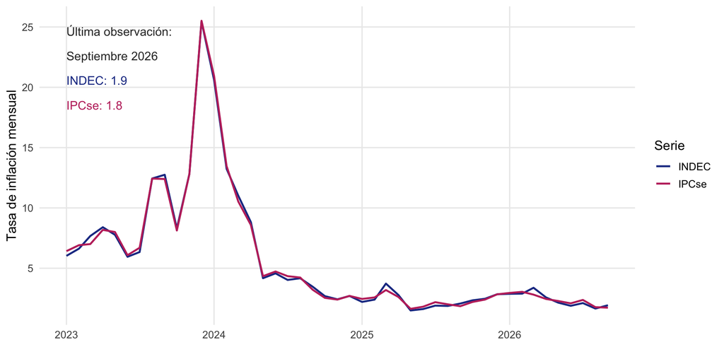

**El Índice de Precios al Consumidor nacional sin estacionalidad (IPCse) aumentó un 1.8 por ciento en Septiembre, luego de haber aumentado un 1.8 por ciento en Agosto.**

En Septiembre los factores estacionales contribuyeron a que la medición oficial de la inflación fuera 0.1 puntos porcentuales mayor que sin estacionalidad, 1.9 por ciento versus 1.8 por ciento. Esta diferencia de 0.1 puntos porcentuales en la inflación oficial de Septiembre se explica fundamentalmente por el comportamiento de la división Prendas de vestir y calzado donde los factores estacionales hicieron que la medición oficial fuera 2.4 puntos porcentuales más alta (Figura 2). Durante los últimos 12 meses, el índice aumentó un 33.4 por ciento antes del ajuste estacional (datos oficiales de INDEC).

**Durante Septiembre, la inflación luego del ajuste estacional fue menor que la medición oficial en todas las regiones.** La mayor diferencia se observó en la región Noreste, con 0.4 puntos porcentuales, seguida por GBA (0.3) y Pampeana (0.3). Las menores diferencias correspondieron a las regiones Patagonia y Cuyo, con 0.1 y 0.1 puntos porcentuales respectivamente (Figura 1).

**El índice de precios de Educación fue el que más aumentó en el mes al ajustar por estacionalidad, con un incremento de 3.7 por ciento.** **En segundo lugar se ubicó Vivienda, agua, electricidad, gas y otros combustibles, con un incremento de 3.1 por ciento.** Le siguen Comunicación (2.5 por ciento) y Salud (2.1 por ciento) (Cuadro 1).

**Los índices de precios de Prendas de vestir y calzado y Restaurantes y hoteles presentaron las menores variaciones al ajustar por estacionalidad, con -1.0 y 1.1 por ciento respectivamente.** Les siguen los índices de Bienes y servicios varios y Bebidas alcohólicas y tabaco, con 1.4 y 1.4 por ciento respectivamente (Figura 2).

**La contribución más importante al dato del nivel general del IPCse de Septiembre la hizo el índice de precios de la división Alimentos y bebidas no alcohólicas, explicando alrededor de 33.1 por ciento del 1.8 por ciento de inflación.** En segundo lugar se posicionó Vivienda, agua, electricidad, gas y otros combustibles, que explica 18.9 por ciento de la medición del mes, seguida por Salud (10.9 por ciento) y Transporte (10.3 por ciento) (Cuadro 2).

**En la comparación interanual, Septiembre de 2026 contra Septiembre de 2025, antes del ajuste estacional, alrededor del 56.4 por ciento del aumento de 33.4 por ciento está explicado por los índices de precios de tres de las divisiones de la canasta: Alimentos y bebidas no alcohólicas, Vivienda, agua, electricidad, gas y otros combustibles y Transporte.** Restaurantes y hoteles, con una incidencia interanual de 3.8 puntos porcentuales, y Salud, con 3.0 puntos porcentuales, son las divisiones que le siguen en la explicación del aumento interanual del nivel general de precios (Cuadro 2).

**En Septiembre, la inflación subyacente, definida como el cambio porcentual en el nivel general del IPCse menos el efecto de los índices de precios de las divisiones de la canasta que incluyen bienes y servicios regulados o con alto componente impositivo, fue de 1.4 por ciento después de haber aumentado un 1.5 por ciento en Agosto.** En comparación con el mes anterior, la inflación subyacente mensual tuvo un comportamiento dispar entre las regiones. En Cuyo la inflación subyacente aumentó respecto del mes anterior, con diferencias de 0.1 punto porcentual; en GBA, Pampeana, Noroeste, Noreste y Patagonia disminuyó, con reducciones de 0.3, 0.2, 0.4, 1.0 y 0.9 puntos porcentuales, respectivamente. La inflación subyacente interanual en el país se ubica en 30.1 por ciento en Septiembre (Cuadro 1).

**Cuadro 1. Cambios porcentuales en el IPCse**

| IPCse Año | Variación mensual 2026 Abr | Variación mensual 2026 May | Variación mensual 2026 Jun | Variación mensual 2026 Jul | Variación mensual 2026 Ago | Variación mensual 2026 Sep | Variación interanual Sep 2026 / Sep 2025 |
| --- | --- | --- | --- | --- | --- | --- | --- |
| IPCse Nacional | 2.4 | 2.3 | 2.1 | 2.4 | 1.8 | 1.8 | 33.4 |
| **Regiones** |  |  |  |  |  |  |  |
| GBA | 2.5 | 2.8 | 2.5 | 2.8 | 1.8 | 1.7 | 33.5 |
| Pampeana | 2.4 | 2.5 | 2.6 | 2.5 | 1.8 | 1.7 | 33.1 |
| Noroeste | 2.3 | 2.6 | 2.2 | 2.5 | 1.7 | 1.6 | 33.6 |
| Noreste | 2.8 | 3.3 | 2.7 | 2.4 | 1.7 | 1.3 | 36.9 |
| Cuyo | 1.9 | 2.4 | 2.0 | 2.1 | 1.6 | 1.8 | 33.0 |
| Patagonia | 2.5 | 2.2 | 2.0 | 2.3 | 1.8 | 1.3 | 30.3 |
| **Divisiones COICOP** |  |  |  |  |  |  |  |
| Alimentos y bebidas no alcohólicas | 1.5 | 2.5 | 1.3 | 2.0 | 1.7 | 2.0 | 35.1 |
| Bebidas alcohólicas y tabaco | 1.9 | 0.8 | 2.1 | 1.5 | 2.1 | 1.4 | 22.4 |
| Prendas de vestir y calzado | 0.5 | 1.6 | 1.9 | 1.3 | 0.9 | -1.0 | 10.3 |
| Vivienda, agua, electricidad, gas y otros combustibles | 3.5 | 2.6 | 3.3 | 2.2 | 2.8 | 3.1 | 49.1 |
| Equipamiento y mantenimiento del hogar | 2.9 | 1.4 | 1.5 | 2.1 | 1.4 | 1.6 | 23.7 |
| Salud | 2.7 | 2.4 | 3.4 | 2.9 | 2.5 | 2.1 | 33.3 |
| Transporte | 4.4 | 2.0 | 1.6 | 1.9 | 1.5 | 1.5 | 36.2 |
| Comunicación | 4.1 | 3.4 | 0.9 | 2.4 | 2.3 | 2.5 | 37.3 |
| Recreación y cultura | 1.0 | 2.8 | 4.2 | 5.0 | 0.0 | 1.9 | 32.2 |
| Educación | 5.6 | 4.3 | 1.8 | 3.5 | 2.5 | 3.7 | 39.9 |
| Restaurantes y hoteles | 2.6 | 1.8 | 1.6 | 2.8 | 1.8 | 1.1 | 34.6 |
| Bienes y servicios varios | 3.2 | 3.1 | 3.1 | 2.3 | 2.4 | 1.4 | 32.5 |
| **Inflación subyacente** |  |  |  |  |  |  |  |
| Nacional | 1.7 | 2.2 | 1.8 | 2.3 | 1.5 | 1.4 | 30.1 |
| GBA | 1.7 | 3.0 | 2.5 | 3.0 | 1.4 | 1.1 | 30.5 |
| Pampeana | 1.8 | 2.5 | 2.7 | 2.7 | 1.4 | 1.2 | 30.4 |
| Noroeste | 1.6 | 2.5 | 2.1 | 2.5 | 1.6 | 1.2 | 30.6 |
| Noreste | 2.1 | 2.8 | 2.5 | 2.0 | 1.5 | 0.5 | 32.5 |
| Cuyo | 1.2 | 2.1 | 2.3 | 1.9 | 1.4 | 1.5 | 29.0 |
| Patagonia | 1.9 | 2.8 | 2.2 | 2.2 | 1.7 | 0.8 | 25.2 |

* Nota: existe una diferencia económicamente no significativa (menos de medio punto porcentual) entre las variaciones interanuales del IPCse y del IPC calculado por INDEC. Debido a esto la última columna del cuadro muestra las variaciones interanuales del IPC oficial.

**Figura 1. Tasa de inflación mensual**

[interactive chart not shown]

**Figura 2. Tasa de inflación mensual en cada división COICOP**

[interactive chart not shown]

**Cuadro 2. Incidencia de las divisiones en la inflación**

|  | GBA | Pampeana | Noroeste | Noreste | Cuyo | Patagonia | Nacional |
| --- | --- | --- | --- | --- | --- | --- | --- |
| **Incidencia mensual (IPCse)** |  |  |  |  |  |  |  |
| Nivel general | 1.65 | 1.71 | 1.63 | 1.27 | 1.82 | 1.26 | 1.75 |
| Alimentos y bebidas no alcohólicas | 0.48 | 0.47 | 0.33 | 0.17 | 0.58 | 0.31 | 0.58 |
| Bebidas alcohólicas y tabaco | 0.02 | 0.02 | 0.01 | 0.01 | 0.02 | 0.02 | 0.03 |
| Prendas de vestir y calzado | -0.17 | -0.04 | 0.01 | -0.10 | -0.04 | -0.03 | -0.07 |
| Vivienda, agua, electricidad, gas y otros combustibles | 0.29 | 0.35 | 0.34 | 0.53 | 0.29 | 0.29 | 0.33 |
| Equipamiento y mantenimiento del hogar | 0.05 | 0.09 | 0.07 | 0.08 | 0.07 | 0.00 | 0.08 |
| Salud | 0.23 | 0.23 | 0.19 | 0.12 | 0.19 | 0.12 | 0.19 |
| Transporte | 0.21 | 0.17 | 0.04 | 0.08 | 0.28 | 0.16 | 0.18 |
| Comunicación | 0.11 | 0.10 | 0.10 | 0.12 | 0.06 | 0.06 | 0.07 |
| Recreación y cultura | 0.09 | 0.15 | 0.20 | 0.09 | 0.10 | 0.11 | 0.12 |
| Educación | 0.10 | 0.06 | 0.11 | 0.06 | 0.04 | 0.14 | 0.08 |
| Restaurantes y hoteles | 0.17 | 0.08 | 0.17 | 0.04 | 0.18 | 0.06 | 0.12 |
| Bienes y servicios varios | 0.08 | 0.04 | 0.07 | 0.06 | 0.04 | 0.03 | 0.05 |
| **Incidencia interanual (INDEC)** |  |  |  |  |  |  |  |
| Nivel general | 33.54 | 33.06 | 33.59 | 36.86 | 33.03 | 30.29 | 33.28 |
| Alimentos y bebidas no alcohólicas | 8.68 | 10.71 | 12.83 | 14.64 | 10.39 | 8.42 | 9.97 |
| Bebidas alcohólicas y tabaco | 0.56 | 0.63 | 0.50 | 0.61 | 0.58 | 0.63 | 0.59 |
| Prendas de vestir y calzado | 0.65 | 0.88 | 1.09 | 0.87 | 1.29 | 1.24 | 0.82 |
| Vivienda, agua, electricidad, gas y otros combustibles | 4.55 | 4.17 | 4.81 | 7.94 | 4.90 | 5.96 | 4.72 |
| Equipamiento y mantenimiento del hogar | 1.32 | 1.31 | 1.20 | 1.29 | 1.18 | 1.17 | 1.29 |
| Salud | 3.22 | 3.22 | 2.34 | 2.01 | 2.78 | 1.88 | 3.02 |
| Transporte | 4.25 | 3.90 | 3.20 | 3.24 | 5.30 | 5.05 | 4.09 |
| Comunicación | 1.02 | 0.94 | 0.86 | 0.93 | 0.74 | 0.86 | 0.95 |
| Recreación y cultura | 2.26 | 2.27 | 1.60 | 1.65 | 1.66 | 1.65 | 2.12 |
| Educación | 1.18 | 0.49 | 0.96 | 0.53 | 0.64 | 0.70 | 0.83 |
| Restaurantes y hoteles | 4.62 | 3.47 | 3.26 | 2.22 | 2.47 | 1.82 | 3.76 |
| Bienes y servicios varios | 1.23 | 1.06 | 0.96 | 0.94 | 1.10 | 0.91 | 1.12 |

* Nota: los ponderadores de los índices de precios de las divisiones para el cálculo de las incidencias del IPC nacional se construyeron como promedio ponderado de las ponderaciones regionales al no existir ponderadores oficiales. Debido a esto, el resultado de la suma de las incidencias da un valor aproximado a la inflación del nivel general.

## NOTA TECNICA

### Breve explicación del IPCse

El Índice de Precios al Consumidor (IPC) que publica mensualmente el Instituto de Estadística y Censos (INDEC) mide el cambio en los precios de una canasta de bienes y servicios adquiridos por los consumidores urbanos. El índice mide cambios de precios con respecto a una fecha de referencia. La fecha de referencia es diciembre de 2016 donde el IPC vale 100. El INDEC publica índices de precios, para diferentes regiones del país y para el total nacional, que no están ajustados por estacionalidad.

Para analizar la evolución de los índices de precios en el corto plazo, los cambios desestacionalizados suelen preferirse ya que eliminan los efectos que normalmente ocurren en la economía, al mismo tiempo y en aproximadamente la misma magnitud cada año. Estos efectos producen movimientos de precios resultantes de fenómenos meteorológicos, ciclos de producción, vacaciones, cambios de estación, etc.

La inflación subyacente se define como la que se obtiene con el IPCse sin el efecto de los índices de precios de las divisiones que contienen los productos regulados o con alto contenido impositivo. En este sentido, la inflación subyacente cumple una función similar a la del denominado IPC núcleo, que calcula el INDEC, excluyendo del nivel general bienes y servicios los estacionales y los regulados. Una diferencia con relación a la inflación núcleo es que en lugar de excluir los precios estacionales, la inflación subyacente los retiene pero les quita la estacionalidad. Una diferencia adicional es que como el IPCse se calcula en base a los datos publicados por el INDEC no puede desagregar los índices de precios de las divisiones que componen la canasta para analizar la estacionalidad de los grupos, clases, subgrupos, y productos que componen cada división.

**¿Cómo se ajustan estacionalmente los índices de precios?**

El movimiento estacional en el nivel general del índice de precios de cada región del país se elimina desestacionalizando cada uno de los índices de las 12 divisiones de la canasta de bienes y servicios de cada región. Después, estos índices desestacionalizados se agregan utilizando los ponderadores publicados por INDEC para las divisiones en la fecha de referencia del IPC: diciembre de 2016. Las divisiones representan los agrupamientos de la Clasificación del Consumo Individual por Finalidad (Classification of Individual Consumption According to Purpose, COICOP, por sus siglas en inglés) elaborada por la Comisión de Estadísticas de las Naciones Unidas (1999) y adaptada por INDEC en 2019.

Para desestacionalizar el IPCse se utiliza el software de ajuste estacional X-13ARIMA-SEATS (promedio móvil integrado autorregresivo) desarrollado por la Oficina del Censo de EE. UU. en 2013. El X-13ARIMA-SEATS utiliza el método de ajuste estacional X-11 junto con el modelo de regresión ARIMA para el análisis de intervención y la proyección de datos. El análisis de intervención se utiliza en el ajuste estacional de los índices de precios al consumidor para proporcionar datos del IPC más precisos. En este sentido, el procedimiento trata de compensar los efectos que la extrema volatilidad de los precios pudiera tener en las estimaciones y proyecciones de los factores estacionales.

El análisis de intervención es el ajuste previo de cada serie de índices antes del cálculo de los factores estacionales. Es posible que se requiera un ajuste previo si se produce un cambio de nivel o un valor atípico. Un cambio de nivel ocurre cuando un bien o servicio experimenta un cambio único, grande y rápido en el nivel de precios. Un valor atípico es un valor extremo para algún mes en particular. Ejemplos recientes de estos potenciales cambios de nivel/valores atípicos pueden verse en los meses en los cuales debido a la pandemia del COVID-19 la política de Aislamiento Social Preventivo y Obligatorio (ASPO) obligó a un cambio de metodología en la recolección de precios (de presencial a no presencial) además de provocar imputaciones por falta de precios de algunos bienes y servicios (restaurantes y hoteles, por ejemplo). La eliminación de estos valores atípicos produce un patrón estacional más claro y da como resultado factores estacionales más estables y que se “ajustan” mejor a la serie histórica. Luego, los factores estacionales se aplican a los datos no ajustados (sin ningún ajuste previo) para calcular el índice ajustado estacionalmente.

Para determinar si el índice de precios de una división tiene estacionalidad se utilizan las medidas de diagnóstico sobre la calidad y estabilidad de la estacionalidad que tiene el método X-11. El X-11 tiene dos estadísticos F que contrastan la presencia de estacionalidad estable. Ambos contrastes paramétricos se basan en la estimación del cociente de la varianza “estacional” y la varianza del componente irregular y utilizan diferentes ajustes del componente de tendencia ciclo. Adicionalmente, el método X-11 provee de un contraste no paramétrico de estacionalidad estable, el estadístico chi-cuadrado de Kruskal-Wallis. El X-11 también tiene medidas de estacionalidad móvil. Si hay mucha estacionalidad móvil la serie no es candidata a desestacionalizarse. El método X-11 tiene un contraste de hipótesis que combina el contraste paramétrico y el no paramétrico para detectar la presencia de estacionalidad estable en la serie. Para medir la cantidad de estacionalidad móvil el método también produce el estadístico M7 que mide la cantidad de estacionalidad móvil comparada con la cantidad de estacionalidad estable, a mayor estacionalidad móvil menor probabilidad de obtener patrones estacionales estables. Por último, el X-11 tiene una medida de la calidad del ajuste estacional (el estadístico Q) que es un promedio ponderado de once estadísticos diferentes. El Manual del X-13ARIMA-SEATS contiene una descripción completa de estos estadísticos.

Para que un índice de precios de una división pueda desestacionalizarse el se usa un criterio muy similar al que utiliza el Bureau of Labor Statistics (BLS) de Estados Unidos en la desestacionalización del Consumer Price Index for All Urban Consumers (CPI-U): contraste paramétrico F≥7; test combinado detectando la presencia de estacionalidad estable además de que los estadísticos M7 y Q sean menores a uno.

Usando estos criterios los índices de precios de las divisiones de la COICOP: alimentos y bebidas no alcohólicas, bebidas alcohólicas y tabaco, prendas de vestir y calzado y educación tienen estacionalidad en las seis regiones del país. Además de estos índices de precios, en la región del GBA, equipamiento y mantenimiento del hogar, transporte, comunicación y recreación y cultura tienen estacionalidad. En la regiones pampeana y noroeste se detecta estacionalidad estable en comunicación y recreación y cultura. En la región noreste hay estacionalidad en los índices de precios de equipamiento y mantenimiento del hogar, comunicación, recreación y cultura y bienes y servicios varios. En la región de Cuyo se detecta estacionalidad en las series de comunicación, recreación y cultura y restaurantes y hoteles. Finalmente, en la región patagónica las series con estacionalidad son equipamiento y mantenimiento del hogar, salud, recreación y cultura y bienes y servicios varios.

Se debe notar que siguiendo estos criterios estadísticos ni el CPI-U de Estados Unidos, ni el IPC nacional tienen estacionalidad detectable, aún cuando incluyen índices de precios más desagregados que sí la tienen. Debido a esto el BLS publica el CPI-U desestacionalizado para analizar las variaciones de precios mes a mes. Para el IPCse se utiliza el mismo procedimiento, se incorpora dentro del IPC a las series desestacionalizadas identificando sus factores estacionales de forma tal de poder cuantificar su impacto mensual, presente y futuro.

El no detectar estacionalidad estable en el nivel general del índice implica que los patrones estacionales de las series más desagregadas se compensan en el agregado. Hay algunos índices de precios de las 12 divisiones de la canasta que a pesar de tener estacionalidad estable tienen un patrón estacional con una amplitud moderada o baja como son las series de alimentos y bebidas no alcohólicas y bebidas alcohólicas y tabaco. Otros índices de precios como educación y prendas de vestir y calzado tienen una estacionalidad más marcada, pero tienen una menor ponderación en la construcción del nivel general. En la región del GBA por ejemplo, el patrón de estacionalidad de prendas de vestir y calzado es un espejo del de recreación y cultura (con ponderadores parecidos en el nivel general), los picos estacionales de la primera serie coinciden con los valles en la segunda y viceversa.

Cada mes de enero, con los datos de los índices hasta diciembre se reevalúa la estacionalidad de cada serie de índices con base en los criterios estadísticos mencionados arriba. Un índice podría cambiar su estado de ajuste estacional de “ajustado estacionalmente” a “no ajustado estacionalmente”, o viceversa. A mediados de febrero de cada año, cuando se publican los datos de inflación de enero, se publicarán nuevos índices ajustados estacionalmente y los nuevos factores de ajuste estacional para cada división. Estos factores de estacionalidad permanecen constantes durante el resto del año. El método X-11 utilizado para el ajuste estacional produce una serie desestacionalizada diferente con cada dato mensual adicional de forma tal que el IPCse debería actualizarse hacia atrás con cada nuevo dato. Para evitar este ajuste mensual en la desestacionalizada los factores estacionales se mantienen constantes durante un año de forma tal de no cambiar hacia atrás la serie sin estacionalidad. Este es el mismo procedimiento que usa el BLS para la construcción del CPI-U desestacionalizado. Cada mes de enero, como se mencionó arriba se actualizan estos factores estacionales y se reconstruye la serie desestacionalizada hasta 5 años hacia atrás. Los factores estacionales de más de 5 años hacia atrás se consideran definitivos.

La última revisión del ajuste estacional se realizó en enero de 2026. Los factores estacionales se re-estiman anualmente con la serie completa hasta diciembre del año previo (en esta edición, diciembre de 2025) mediante X-13ARIMA-SEATS. Con esos modelos se proyectan los factores del año en curso (2026), que se aplican al IPC observado de cada mes sin re-estimar dentro del año —de modo de no revisar la serie hacia atrás—, siguiendo la práctica del Bureau of Labor Statistics. En base a este criterio, los factores estacionales para el período diciembre de 2016 a diciembre de 2020 se consideran definitivos, mientras que los posteriores fueron estimados con la información más reciente.